# Data science per psicologi - demo 15.01

Corrado Caudek

2022-03-29

```r
suppressPackageStartupMessages({
  library("here")
  library("tidyverse")
  library("scales")
  library("bayesplot")
  library("distrEx")
  library("bayesrules")
})

theme_set(bayesplot::theme_default(base_size = 12))
bayesplot::color_scheme_set("gray")
set.seed(84735)

knitr::opts_chunk$set(
  collapse = TRUE,
  tidy = 'styler',
  fig.width = 6,
  fig.asp = 0.618 # 1 / phi
)
```

# L’inferenza bayesiana

Consideriamo nuovamente i dati di Zetsche et al. (2019), ovvero 23 successi in 30 prove. Abbiamo visto come il modello generativo per i dati è

$$y \sim \mbox{Binom}(n, \theta).$$

Il parametro ignoto $\theta$ è l’oggetto dell’inferenza.

## L’aggiornamento bayesiano

L’inferenza si svolge mediante l’aggiornamento bayesiano:

$$p(\theta \mid y) = \frac{p(y \mid \theta) p(\theta)}{\int_{\Theta}p(y
\mid \theta) p(\theta) \,\operatorname {d}\!\theta}, \quad \theta \in
\Theta.$$

### Un esempio concreto

Consideriamo ora un’approssimazione discreta all’equazione precedente, ovvero il caso in cui vengono esaminati soltanto 20 possibili valori $\theta$:

```r
n <- 20
theta <- seq(0, 1, length.out = n)
theta
```

```
##  [1] 0.00000000 0.05263158 0.10526316 0.15789474 0.21052632 0.26315789
##  [7] 0.31578947 0.36842105 0.42105263 0.47368421 0.52631579 0.57894737
## [13] 0.63157895 0.68421053 0.73684211 0.78947368 0.84210526 0.89473684
## [19] 0.94736842 1.00000000
```

### La distribuzione a priori

Decidiamo di descrivere le nostre opinioni a priori sui valori possibili del parametro $\theta$ mediante una distribuzione Beta di parametri $\alpha = 23.4$ e $\beta = 6.6$.

```r
alpha <- 23.4
beta <- 6.6
```

ovvero

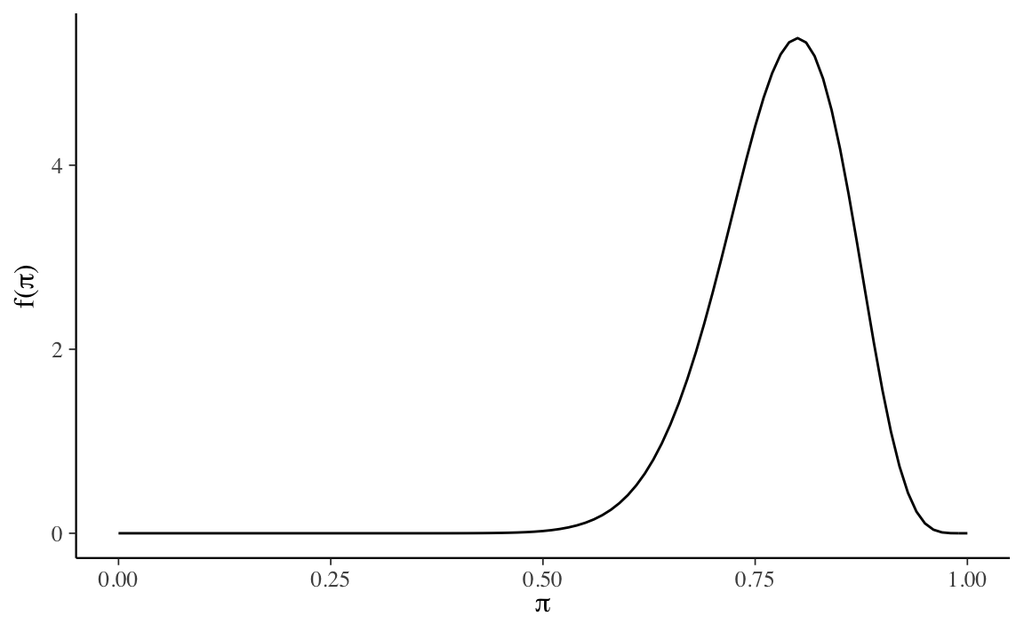

```r
plot_beta(alpha, beta, mean = FALSE, mode = FALSE)
```

Dato che esaminiamo soltanto 20 valori $\theta$, discretizziamo la distribuzione a priori in modo da considerare l’ordinata della distribuzione Beta solo in corrispondenza dei 20 valori $\theta$ considerati:

```r
fx <- dbeta(theta, alpha, beta)
```

Dato che abbiamo discretizzato la variabile casuale $\theta$, dobbiamo generare una funzione di massa di probabilità – ovvero dobbiamo fare in modo che la somma dei valori di probabilità considerati sia uguale a 1:

```r
prior <- fx / sum(fx)
sum(prior)
```

```
## [1] 1
```

La distribuzione a priori discretizzata diventa dunque:

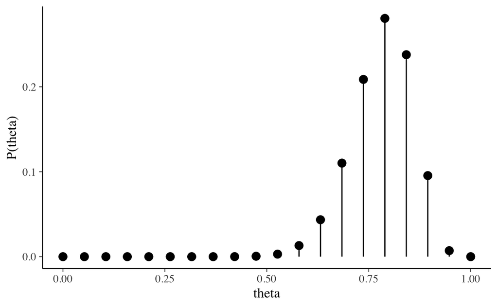

```r
tibble(
  x = theta,
  y = prior
) %>%
  ggplot(aes(x, y)) +
  geom_point(size = 3) +
  geom_linerange(aes(x = x, ymax = y, ymin = 0)) +
  labs(
    x = "theta",
    y = "P(theta)"
  )
```

### La funzione di verosimiglianza

Per generare la funzione di verosimiglianza dobbiamo utilizzare il modello Binomiale tenendo costante i dati $y = 23, n = 30$ e variando il valore $\theta$. Per i 20 possibili valori $\theta$ che stiamo considerando, otteniamo:

```r
like <- dbinom(23, 30, theta)
like
```

```
##  [1] 0.000000e+00 5.407974e-24 3.040601e-17 2.232317e-13 1.062052e-10
##  [6] 1.110027e-08 4.377330e-07 8.662649e-06 1.016121e-04 7.828973e-04
## [11] 4.224980e-03 1.658780e-02 4.819278e-02 1.032483e-01 1.584389e-01
## [16] 1.624224e-01 9.566112e-02 2.257679e-02 6.567419e-04 0.000000e+00
```

Una rappresentazione grafica della funzione di verosimiglianza (discretizzata) è

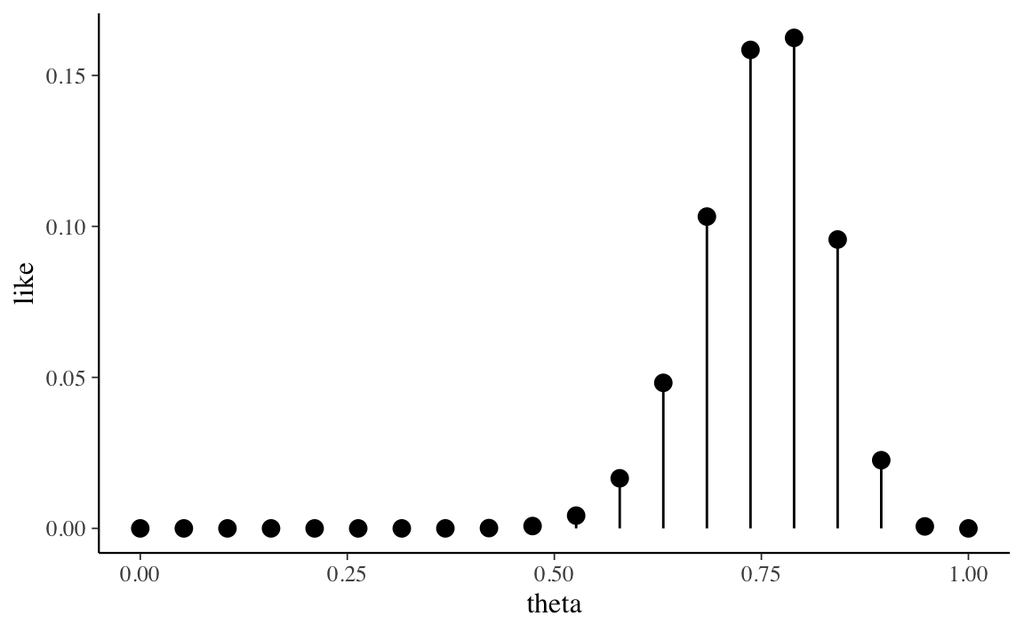

```r
tibble(theta, like) %>%
  ggplot(aes(x = theta, y = like)) +
  geom_point(size = 3) +
  geom_linerange(aes(x = theta, ymax = like, ymin = 0))
```

### La distribuzione a posteriori

La distribuzione a posteriori, $p(\theta \mid y)$, è *proporzionale* al prodotto della distribuzione a priori e della verosimiglianza.

```r
post_distr <- like * prior
```

Se ora calcolo la somma dei valori della distribuzione a posteriori (discretizzata), mi rendo conto che non è 1:

```r
sum(post_distr)
```

```
## [1] 0.1172556
```

Pertanto, normalizzo:

```r
post <- post_distr / sum(post_distr)
sum(post)
```

```
## [1] 1
```

Una rappresentazione grafica della distribuzione a posteriori (normalizzata) si ottiene nel modo seguente:

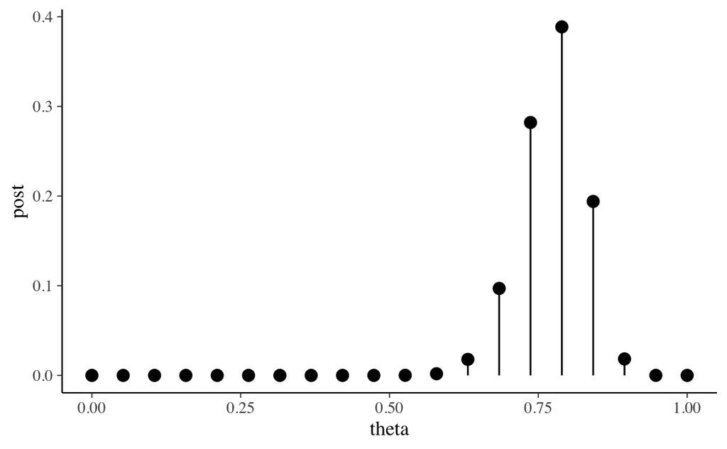

```r
tibble(theta, post) %>%
  ggplot(aes(x = theta, y = post)) +
  geom_point(size = 3) +
  geom_linerange(aes(x = theta, ymax = post, ymin = 0))
```

Se immaginiamo di ripetere la procedura descritta sopra con tanti punti $\theta$ (anziché solo 20), congiungendo i punti otteniamo una linea continua. Tale curva rappresenta la funzione di densità a posteriori.